# Script DivOC_script.R

## Script `DivOC_script.R`

### Comenzaremos usando la paquetería `DiversityOccupancy`

Este paquete estima la diversidad alfa por medio de modelos jerárquicos.

```r
# 1. Instalar y cargar el paquete ----

# install.packages("DiversityOccupancy")

library(DiversityOccupancy)
library(camtrapR)
library(tidyverse)
library(hillR) # Estimar diversidad
library(ggeffects) #gráficas de pred para glm
library(beepr) # Opcional para avisar R termine
library(tictoc) # Opcional para tomar el tiempo de la función
```

## Este paquete te va a pedir instalar también `MuMIn`, `unmarked`, `reshape`, `lattice`, `Rcpp`

## Formato de los datos

Son necesarios eventos de muestreo repetidos.

> **Nota**: Todas las especies deben tener una matriz de historias de detección de las mismas dimensiones

```r
# Cargamos la tabla de registros de las especies
registers <-  read.csv("Data/Survey/recordTable_OC.csv")
table(registers$Species)
```

```
##
##      Bassariscus astutus            Canis latrans   Canis lupus familiaris
##                        3                        6                        4
##             Capra hircus     Conepatus leuconotus     Dasypus novemcinctus
##                       13                       79                        1
##               Lynx rufus        Mephitis macroura             Nasua narica
##                       50                       18                        4
##   Odocoileus virginianus            Pecari tajacu            Procyon lotor
##                      227                       71                       40
##        Puma yagouaroundi                 Roedores   Spilogale angustigrons
##                        6                       66                       13
##    Sylvilagus floridanus Urocyon cinereoargenteus
##                      492                      173
```

```r
# Cargamos la tabla de operación de cámaras
CToperation <-  read.csv("Data/Survey/CTtable_OC.csv")

# Generamos la matríz de operación de las cámaras
library(camtrapR)
camop <- cameraOperation(CTtable= CToperation, # Tabla de operación
                         stationCol= "Station", # Columna que define la estación
                         setupCol= "Setup_date", #Columna fecha de colocación
                         retrievalCol= "Retrieval_date", #Columna fecha de retiro
                         hasProblems= T, # Hubo fallos de cámaras
                         dateFormat= "%Y-%m-%d") # Formato de las fechas
```

```r
# Función para generar las historias de detección para todas las especies seleccionadas

DetHist_list <- lapply(unique(registers$Species), FUN = function(x) {
  detectionHistory(
    recordTable         = registers, # Tabla de registros
    camOp                = camop, # Matriz de operación de cámaras
    stationCol           = "Station",
    speciesCol           = "Species",
    recordDateTimeCol    = "DateTimeOriginal",
    recordDateTimeFormat  = "%d/%m/%Y",
    species              = x,     # la función reemplaza x por cada una de las especies
    occasionLength       = 10,  # Colapso de las historias a 10 días
    day1                 = "station", #inicie en la fecha de cada estación
    datesAsOccasionNames = FALSE,
    includeEffort        = TRUE,
    scaleEffort          = TRUE,
    timeZone             = "America/Mexico_City"
  )}
)
# Se genera una lista con cada historia de detección y el esfuerzo de muestreo, ahora le colocaremos los nombres para saber a cual especie corresponde
names(DetHist_list) <- unique(registers$Species)

# Finalmente creamos una lista nueva donde estén solo las historias de detección
ylist <- lapply(DetHist_list, FUN = function(x) x$detection_history)

# Todas las historias deben tener el mismo número de sitios y de ocasiones de muestreo

data <- ylist %>% # Lista con los datos
  reduce(cbind) # Unimos las historias de captura en un solo dataframe
```

|  | o1 | o2 | o3 | o4 | o5 | o6 | o7 | o8 | o9 | o10 | o11 | o12 | o13 | o14 | o15 | o16 | o17 | o18 | o19 | o1 | o2 | o3 | o4 | o5 | o6 | o7 | o8 | o9 | o10 | … |
| --- | --- | --- | --- | --- | --- | --- | --- | --- | --- | --- | --- | --- | --- | --- | --- | --- | --- | --- | --- | --- | --- | --- | --- | --- | --- | --- | --- | --- | --- | --- |
| C1T2P1 | 0 | 0 | 0 | 0 | 0 | 0 | 1 | 0 | 0 | 0 | NA | NA | NA | NA | NA | NA | NA | NA | NA | 0 | 0 | 0 | 0 | 1 | 1 | 1 | 0 | 0 | 0 | … |
| C1T2P11 | NA | NA | NA | 1 | 0 | 1 | 0 | 1 | 0 | 0 | NA | NA | NA | NA | NA | NA | NA | NA | NA | NA | NA | NA | 0 | 0 | 0 | 0 | 0 | 0 | 0 | … |
| C1T2P21 | 0 | 0 | 0 | 0 | 0 | 0 | 0 | 0 | 1 | 0 | NA | NA | NA | NA | NA | NA | NA | NA | NA | 0 | 0 | 0 | 0 | 0 | 0 | 0 | 0 | 0 | 0 | … |
| C1T4P1 | 0 | 0 | 0 | 0 | 0 | 0 | 0 | 0 | 0 | 0 | NA | NA | NA | NA | NA | NA | NA | NA | NA | 0 | 0 | 0 | 0 | 0 | 0 | 0 | 0 | 0 | 0 | … |
| C1T4P11 | 1 | 0 | 1 | 0 | 0 | 0 | 1 | 1 | 1 | 0 | NA | NA | NA | NA | NA | NA | NA | NA | NA | 0 | 0 | 0 | 0 | 0 | 0 | 0 | 0 | 1 | 0 | … |
| C1T4P21 | 0 | 0 | 0 | 0 | 0 | 0 | 0 | 0 | 0 | 0 | NA | NA | NA | NA | NA | NA | NA | NA | NA | 0 | 0 | 0 | 0 | 0 | 0 | 0 | 0 | 0 | 0 | … |

# Cargar las covariables

Vamos a leer el archivo .csv de la ruta `data/Covs/` que contiene las covariables de sitio (no usaremos de observación). Todas estas estandarizadas

```r
# Ahora cargamos las covariables (previamente estandarizadas)
covars <- read.csv("Data/Covs/stdcovs_OC.csv") %>%
  select(-"...1", -X, -Station, -Cam, -Cluster) # Las gráficas no funcionan con categóricas
```

| Vertcover_50 | Dcrops | MSAVI | Slope | Effort | Dpop_G |
| --- | --- | --- | --- | --- | --- |
| -0.4744602 | 0.6765368 | 0.7316819 | -0.2195550 | -0.2080680 | -0.4260974 |
| 0.6519157 | 1.4620448 | -0.8666152 | -0.9927301 | -1.4605398 | -0.3167450 |
| -0.9243340 | 2.2193059 | -0.5838870 | -1.0258694 | -0.0719298 | -0.1805434 |
| -0.9243340 | 0.4603495 | -0.1430110 | 1.4183658 | -0.8887592 | -0.1922714 |

> **Importante**: Cada proceso es afectado por diferentes covariables. Para más información mira este **[enlace](https://mmeredith.net/blog/2021/Polar_bear.htm?fbclid=IwAR2XKX0X9Lu-Bqu2skniXNJV54dsMqy0lb7AdFZpoCR4ZN1E5Yt71rLvgF4)**

# Manos a la obra

### Vamos a utilizar la función `diversityoccu()`

Se genera un objeto lista con los modelos para cada una de las especies, cálculo de diversidad y otras cosas….

```r
cam_diver <- diversityoccu(pres = data, # La matriz de datos
     sitecov = covars, # Covariables de sitio
     obscov = NULL, # no tenemos covariables de observación,
     spp = 16, # Número de especies
     form = ~ Effort + Slope ~ Dcrops, # Formula del modelo p(), lambda()
     dredge = FALSE # En este primer ejemplo no usaremos AIC
     )
```

```
## [1] "Species 1 ready!"
## [1] "Species 2 ready!"
## [1] "Species 3 ready!"
## [1] "Species 4 ready!"
## [1] "Species 5 ready!"
## [1] "Species 6 ready!"
## [1] "Species 7 ready!"
## [1] "Species 8 ready!"
## [1] "Species 9 ready!"
## [1] "Species 10 ready!"
## [1] "Species 11 ready!"
## [1] "Species 12 ready!"
## [1] "Species 13 ready!"
## [1] "Species 14 ready!"
## [1] "Species 15 ready!"
## [1] "Species 16 ready!"
```

Se va a generar un objeto lista con los modelos para cada una de las especies, cálculo de diversidad y otras cosas….

### Veamos uno de los modelos 🐺

```r
cam_diver$models[[9]] # Modelo para la especie 9
```

```
##
## Call:
## occuRN(formula = form, data = data2)
##
## Abundance:
##             Estimate    SE     z  P(>|z|)
## (Intercept)   -1.643 0.322 -5.11 3.25e-07
## Dcrops        -0.483 0.311 -1.55 1.20e-01
##
## Detection:
##             Estimate    SE      z P(>|z|)
## (Intercept)   -0.540 0.376 -1.436 0.15091
## Effort        -1.919 0.576 -3.333 0.00086
## Slope          0.138 0.301  0.458 0.64725
##
## AIC: 190.8491
```

# El problema…..

No sabemos si todas las especies responden de la misma manera a las covariables que usamos. Debemos escoger de todas las variables cual se ajusta mejor a cada especie

### ¿Cómo vamos a generar todas las posibles combinaciones de modelos para cada especie?

Tranquilo esta misma función lo hace por ti :D

## Solamente tenemos que activar `dredge`

Dependiendo de tu computador la función puede tardar más o menos. En la mía duró ~57 segs. Pero puede tardar mucho más dependiendo del número de especies, sitios, eventos de muestreo y cantidad de covariables.

```r
cam_diver_AIC <- diversityoccu(pres = data, # La matriz de datos
                           sitecov = covars, # Covariables de sitio
                           obscov = NULL, # no tenemos covariables de observación,
                           spp = 17, # Número de especies
                           form = ~ Effort + Slope ~ Dcrops, # Formula del modelo p(), lambda()
                           dredge = TRUE # escoge los mejores modelos con AIC
)
```

## Veamos de nuevo el modelo que seleccionó para la sp9 🐺

```r
cam_diver$models[[9]]
```

```
##
## Call:
## occuRN(formula = form, data = data2)
##
## Abundance:
##             Estimate    SE     z  P(>|z|)
## (Intercept)   -1.643 0.322 -5.11 3.25e-07
## Dcrops        -0.483 0.311 -1.55 1.20e-01
##
## Detection:
##             Estimate    SE      z P(>|z|)
## (Intercept)   -0.540 0.376 -1.436 0.15091
## Effort        -1.919 0.576 -3.333 0.00086
## Slope          0.138 0.301  0.458 0.64725
##
## AIC: 190.8491
```

```r
cam_diver_AIC$models[[9]]
```

```
##
## Call:
## occuRN(formula = ~Effort + Slope + 1 ~ 1, data = data2)
##
## Abundance:
##  Estimate    SE      z P(>|z|)
##    -0.145 0.272 -0.532   0.595
##
## Detection:
##             Estimate    SE     z  P(>|z|)
## (Intercept)   -2.846 0.333 -8.54 1.30e-17
## Effort         0.925 0.308  3.01 2.62e-03
## Slope         -0.596 0.215 -2.77 5.58e-03
##
## AIC: 315.6987
```

### Veamos el resultado gráfico para la especie 3 🐗

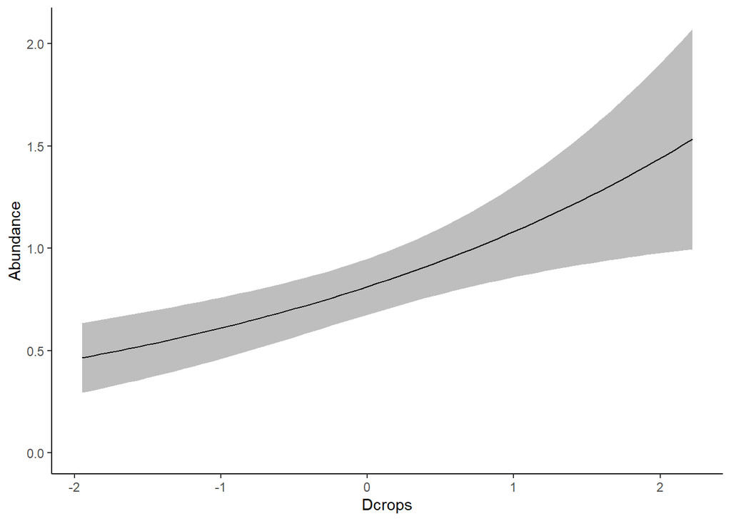

```r
(responseplot.abund( batch = cam_diver_AIC, # objeto creado con diversityoccu
                    spp = 3, # número o nombre de la sp
                    variable= Dcrops # variable
))
```

# Momento de la diversidad

Tenemos un modelo donde se estima la abundancia para cada especie, es hora de modelar la diversidad

```r
glm.div <- model.diversity(DivOcc = cam_diver_AIC,# modelos
                           method = "h", # método
                           delta = 2,
                           squared = T # términos cuadráticos
                                                     )
```

# Momento de la diversidad

```r
AICtab <- glm.div$Table
```

| model | aicc | weights | Delta.AICc |
| --- | --- | --- | --- |
| Diversity ~ 1 + Dcrops + I(Dcrops^2) | -331.8899 | 0.3229081 | 0.0000000 |
| Diversity ~ 1 + Vertcover_50 + Dcrops + I(Dcrops^2) | -331.3285 | 0.2438852 | 0.5613404 |
| Diversity ~ 1 + Dcrops + MSAVI + I(Dcrops^2) | -330.5617 | 0.1662141 | 1.3281821 |
| Diversity ~ 1 + Dcrops + MSAVI + I(Dcrops^2) + I(MSAVI^2) | -330.3166 | 0.1470432 | 1.5732824 |
| Diversity ~ 1 + Dcrops + Dpop_G + I(Dcrops^2) | -329.9093 | 0.1199495 | 1.9805941 |

### Ahora veamos la respuesta gráfica de la diversidad a una variable

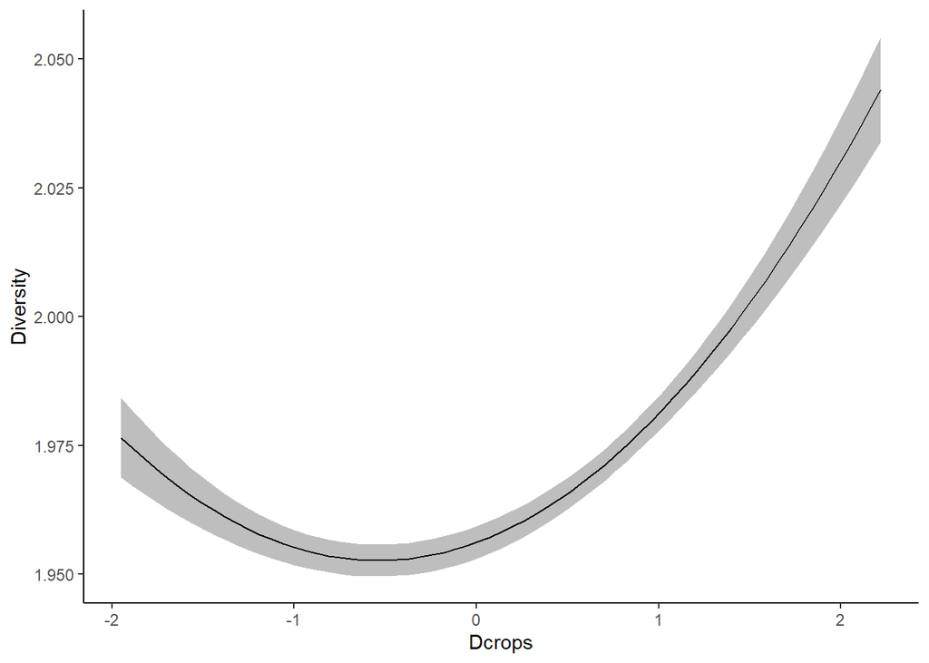

```r
responseplot.diver(glm.div, Dcrops)
```

# Relativamente fácil

[figure not shown]

# Diversidad….

Si seguimos la viñeta del paquete nunca nos dice que elemento de la diversidad mide o calcula..

- Riqueza?
- Shannon, simpson?….
- Número efectivo de especies?? (Hill)

# Glm? de que tipo?

Un Glm puede ser de varias familias (distribuciones) y depende de la naturaleza de los datos: conteos, proporciones, unos y ceros

# Es importante leer el manual

Hay otro argumento de la función `diversityoccu` y es *“index”*. Este argumento permite escoger que índice utilizar **“shannon”**, **“simpson”** o **“invsimpson”**.

```r
cam_diver_sh <- diversityoccu(pres = data,
                           sitecov = covars,
                           obscov = NULL,
                           spp = 17,
                           form = ~ Effort + Slope ~ Dcrops,
                           dredge = TRUE,
                           index = "shannon" #<<
)
```

## Podemos aplicar la función para cada índice…?

> También se puede hacer una función que lo haga en automático, pero por simplicidad (no se hacerlo bien) corremos tres veces la función

```r
cam_diver_sim <- diversityoccu(pres = data,
                           sitecov = covars,
                           obscov = NULL,
                           spp = 17,
                           form = ~ Effort + Slope ~ Dcrops,                            dredge = TRUE,
                           index = "simpson" #<<
)

cam_diver_inv <- diversityoccu(pres = data,
                           sitecov = covars,
                           obscov = NULL,
                           spp = 17,
                           form = ~ Effort + Slope ~ Dcrops,                            dredge = TRUE,
                           index = "invsimpson" #<<
)
```

# Índices de entropía …..

El problema de estos índices (para los ecólogos) es que - son adimensionales - no siguen una relación lineal con la riqueza (doble de riqueza $\neq$ doble de diversidad)

### Calculemos el número efectivo de especies con las abundancias estimadas

```r
# Extraer los datos de abundancia
hill_data <- cam_diver_inv[[4]] %>%
  select(-h)
```

Sospechoso…

| species.1 | species.2 | species.3 | species.4 | species.5 | species.6 | species.7 | species.8 | species.9 | species.10 | species.11 | species.12 | species.13 | species.14 | species.15 | species.16 | species.17 |
| --- | --- | --- | --- | --- | --- | --- | --- | --- | --- | --- | --- | --- | --- | --- | --- | --- |
| 0.6082829 | 1.179013 | 0.9865411 | 0.7986634 | 0.6344777 | 0.470707 | 1.73449 | 2.942110 | 0.8654214 | 0.1201388 | 8.197757 | 0.1485776 | 8.906907 | 0.0098931 | 0.119418 | 11.43433 | 0.2379503 |
| 0.6082829 | 1.179013 | 1.2351996 | 0.7986634 | 0.6344777 | 0.470707 | 1.73449 | 6.441039 | 0.8654214 | 0.1201388 | 8.197757 | 0.1485776 | 8.906907 | 0.0014365 | 0.119418 | 11.43433 | 0.2379503 |
| 0.6082829 | 1.179013 | 1.5340820 | 0.7986634 | 0.6344777 | 0.470707 | 1.73449 | 13.709316 | 0.8654214 | 0.1201388 | 8.197757 | 0.1485776 | 8.906907 | 0.0002236 | 0.119418 | 11.43433 | 0.2379503 |
| 0.6082829 | 1.179013 | 0.9273586 | 0.7986634 | 0.6344777 | 0.470707 | 1.73449 | 2.371387 | 0.8654214 | 0.1201388 | 8.197757 | 0.1485776 | 8.906907 | 0.0168258 | 0.119418 | 11.43433 | 0.2379503 |
| 0.6082829 | 1.179013 | 1.1369200 | 0.7986634 | 0.6344777 | 0.470707 | 1.73449 | 4.824359 | 0.8654214 | 0.1201388 | 8.197757 | 0.1485776 | 8.906907 | 0.0029269 | 0.119418 | 11.43433 | 0.2379503 |
| 0.6082829 | 1.179013 | 1.4022314 | 0.7986634 | 0.6344777 | 0.470707 | 1.73449 | 10.022276 | 0.8654214 | 0.1201388 | 8.197757 | 0.1485776 | 8.906907 | 0.0004836 | 0.119418 | 11.43433 | 0.2379503 |

# Calculemos diversidad con `hillR`

```r
# calcular los perfiles de diversidad
q0 <- hill_taxa(hill_data, q=0)
q1 <- hill_taxa(hill_data, q=1)
q2 <- hill_taxa(hill_data, q=2)
```

Ahora unimos las bases de datos y las covariables para modelar

```r
# Unir las bases de perfiles de diversidad
hill_div <- data.frame(q0=q0, q1=q1, q2=q2)
# Unir con las covariables
glm_hill <- cbind(hill_div, covars)
```

# Obtenemos esta base

| q0 | q1 | q2 | Vertcover_50 | Dcrops | MSAVI | Slope | Effort | Dpop_G |
| --- | --- | --- | --- | --- | --- | --- | --- | --- |
| 17 | 7.289319 | 5.282369 | -0.4744602 | 0.6765368 | 0.7316819 | -0.2195550 | -0.2080680 | -0.4260974 |
| 17 | 7.475290 | 5.686556 | 0.6519157 | 1.4620448 | -0.8666152 | -0.9927301 | -1.4605398 | -0.3167450 |
| 17 | 7.067675 | 5.417599 | -0.9243340 | 2.2193059 | -0.5838870 | -1.0258694 | -0.0719298 | -0.1805434 |
| 17 | 7.202937 | 5.171999 | -0.9243340 | 0.4603495 | -0.1430110 | 1.4183658 | -0.8887592 | -0.1922714 |
| 17 | 7.447582 | 5.557032 | -1.1509622 | 1.1723154 | 0.2129457 | -0.0597006 | -0.0719298 | -0.0948151 |
| 17 | 7.341428 | 5.685354 | 0.6519157 | 1.9052628 | 0.5284530 | -1.0258694 | -0.0719298 | 0.0268169 |